# Marty’s weight

Marton Kiss MD

2025-01-13

## Motivation

I have an excel file with all of my (known) recorded weights including the ones I recorded when I was into (extended) intermittent fasting. I want to fit an intuitive model describing my mass as a function of time.

My long term motivation is to both build a descriptive model of my weight and also to build a predictive model to forecast my weight for the next 30 days in the hopes of that my recent changes would inform the model and me what to expect given a somewhat constant set of behavior.

It seems that after the optimization presented below the resulting model can achieve both goals.

# Methods

I’m using natural splines with a method for determining knot placements; I’m setting a knot after ‘**k**’ days of valid observations.

A necessary exercise is to determine the ‘best’ value for ‘k’.

Another parameter is the number of observations after the last knot (**d**), as in is it better for prediction purposes to have the last knot closer to the borders of the data (outside of which the function is linear) or to have some data after the last knot.

For optimizing **k** and **d**, I used **rolling forecasts**, as in: - fitting a model with a given *d* & *k* on data up until a certain date - predicting all observations based on the model after that date during a 30 day window - calculating the *RMSE* between the predicted and observed values - repeating the above steps when the data used for model fitting (the training data) gets extended anoter 30 days - summing up the RMSEs for each model which was fitted - See what *k,d* pair produces the smallest summed up RMSE

(Note: This optimization is somewhat lengthy, so it was done once and I did not update it since 2023-11-20).

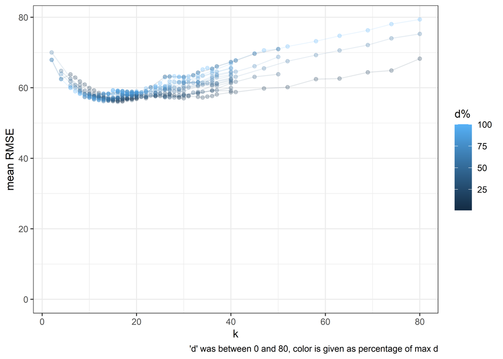

```r
library(dplyr)
library(ggplot2)

res_path <- here::here("inst", "spliney", "crossval_results",
    "roll_forecast_lastday_results.rdata")
load(file = res_path)

out_groupped <- out %>%
    group_by(k, days_before_last) %>%
    mutate(mad_mean = mean(mad, na.rm = TRUE), rmse_mean = mean(rmse,
        na.rm = TRUE), cor_mean = mean(abs(cor.), na.rm = TRUE),
        nas = sum(is.na(mad))) %>%
    slice(1)


out_groupped %>%
    mutate(days_before_last_perc = days_before_last_perc * 100) %>%
    dplyr::rename(`d%` = "days_before_last_perc") %>%
    ggplot(aes(x = k, y = rmse_mean, group = `d%`, color = `d%`)) +
    theme_bw() + scale_y_continuous(limits = c(0, max(out_groupped$rmse_mean))) +
    geom_point(alpha = 0.25) + geom_line(alpha = 0.125) + labs(y = "mean RMSE",
    caption = "'d' was between 0 and 80, color is given as percentage of max d")
```